# Current depressive status

# 1 Description of DataSchema variable

The description of harmonised variable is the following:

- Short name: `depression`
- Variable label: `Current depressive status of the participant`
- Variable description: `Current depressive status of the participant`
- Domain: `Psycological measures`
- Value type: `categorical`
- Category coding:

| **Code** | **Category Label** |
| --- | --- |
| 0 | no depression |
| 1 | depression |

- Category missings:

| **Code** | **Category Label** |
| --- | --- |
| 991 | CAPI/interviewer error |
| 992 | Impute |
| 993 | Disable to measure |
| 994 | Not attempt/not done |
| 995 | Does not answer |
| 996 | Not applicable |
| 997 | Refuse |
| 998 | Do not know |
| 999 | Missing |

# 2 Data process

## 2.1 England

### 2.1.1 Wave 1

#### 2.1.1.1 Study-specific variable description

| **Name** | `psceda` | `pscedb` | `pscedc` | `pscedd` | `pscede` | `pscedf` | `pscedg` | `pscedh` |
| --- | --- | --- | --- | --- | --- | --- | --- | --- |
| **Label** | `Much of the time during the past week, have you felt depressed?` | `Much of the time during the past week, have you felt that everything you did was an effort?` | `Much of the time during the past week, has your sleep been restless?` | `Much of the time during the past week, were you happy?` | `Much of the time during the past week, have you felt lonely?` | `Much of the time during the past week, have you enjoyed life?` | `Much of the time during the past week, have you felt sad?` | `Much of the time during the past week, could you not get going?` |
| **Table name** | `wave_1_core_data_v3` | `wave_1_core_data_v3` | `wave_1_core_data_v3` | `wave_1_core_data_v3` | `wave_1_core_data_v3` | `wave_1_core_data_v3` | `wave_1_core_data_v3` | `wave_1_core_data_v3` |
| **Categories** | `1 = yes` | `1 = yes` | `1 = yes` | `1 = yes` | `1 = yes` | `1 = yes` | `1 = yes` | `1 = yes` |
|  | `2 = no` | `2 = no` | `2 = no` | `2 = no` | `2 = no` | `2 = no` | `2 = no` | `2 = no` |
| **Missing** | `-9 = Refusal` | `-9 = Refusal` | `-9 = Refusal` | `-9 = Refusal` | `-9 = Refusal` | `-9 = Refusal` | `-9 = Refusal` | `-9 = Refusal` |
|  | `-8 = Don't Know` | `-8 = Don't Know` | `-8 = Don't Know` | `-8 = Don't Know` | `-8 = Don't Know` | `-8 = Don't Know` | `-8 = Don't Know` | `-8 = Don't Know` |
|  | `-1 = Not applicable` | `-1 = Not applicable` | `-1 = Not applicable` | `-1 = Not applicable` | `-1 = Not applicable` | `-1 = Not applicable` | `-1 = Not applicable` | `-1 = Not applicable` |
| **Description** |  |  |  |  |  |  |  |  |

Current depressive status

| Sample size | Missing values |
| --- | --- |
| 12099 | 311 |

Category

|  | -9 | -8 | 1 | 2 |
| --- | --- | --- | --- | --- |
| Frequency | 44.00 | 27.00 | 2084.00 | 9633.00 |
| Percentage | 0.36 | 0.22 | 17.22 | 79.62 |

Type of missing

|  | -17 | -1 | NA |
| --- | --- | --- | --- |
| Frequency | 0 | 311.00 | 0 |
| Percentage | 0 | 2.57 | 0 |

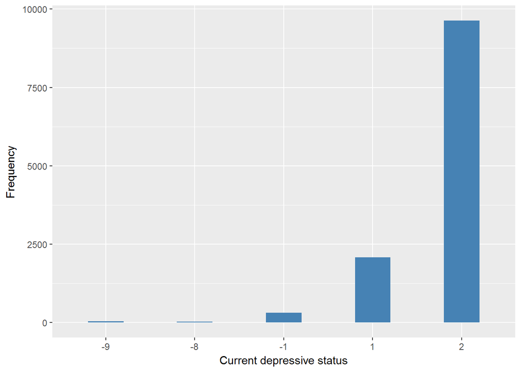

Current depressive status

| Sample size | Missing values |
| --- | --- |
| 12099 | 311 |

Category

|  | -9 | -8 | 1 | 2 |
| --- | --- | --- | --- | --- |
| Frequency | 44.00 | 34.00 | 2768.00 | 8942.00 |
| Percentage | 0.36 | 0.28 | 22.88 | 73.91 |

Type of missing

|  | -17 | -1 | NA |
| --- | --- | --- | --- |
| Frequency | 0 | 311.00 | 0 |
| Percentage | 0 | 2.57 | 0 |

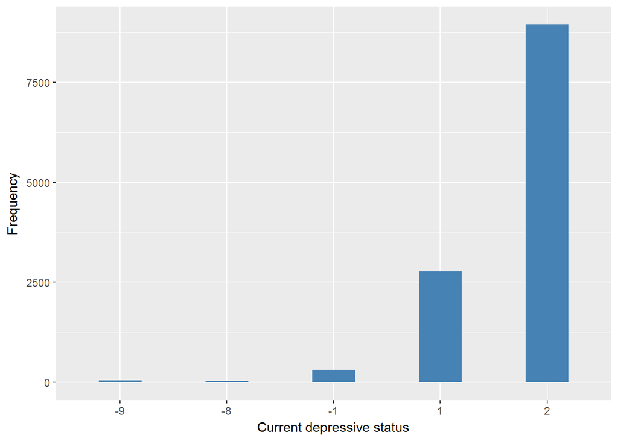

Current depressive status

| Sample size | Missing values |
| --- | --- |
| 12099 | 311 |

Category

|  | -9 | -8 | 1 | 2 |
| --- | --- | --- | --- | --- |
| Frequency | 43.00 | 27.00 | 4776.00 | 6942.00 |
| Percentage | 0.36 | 0.22 | 39.47 | 57.38 |

Type of missing

|  | -17 | -1 | NA |
| --- | --- | --- | --- |
| Frequency | 0 | 311.00 | 0 |
| Percentage | 0 | 2.57 | 0 |

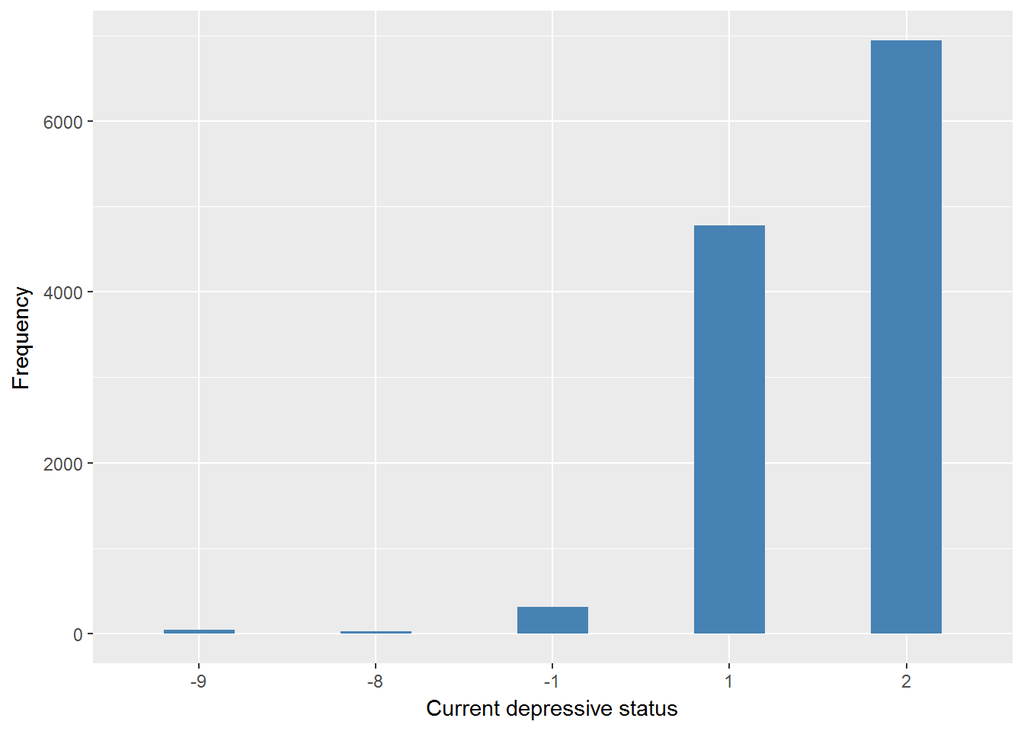

Current depressive status

| Sample size | Missing values |
| --- | --- |
| 12099 | 311 |

Category

|  | -9 | -8 | 1 | 2 |
| --- | --- | --- | --- | --- |
| Frequency | 44.00 | 64.00 | 10374.00 | 1306.00 |
| Percentage | 0.36 | 0.53 | 85.74 | 10.79 |

Type of missing

|  | -17 | -1 | NA |
| --- | --- | --- | --- |
| Frequency | 0 | 311.00 | 0 |
| Percentage | 0 | 2.57 | 0 |

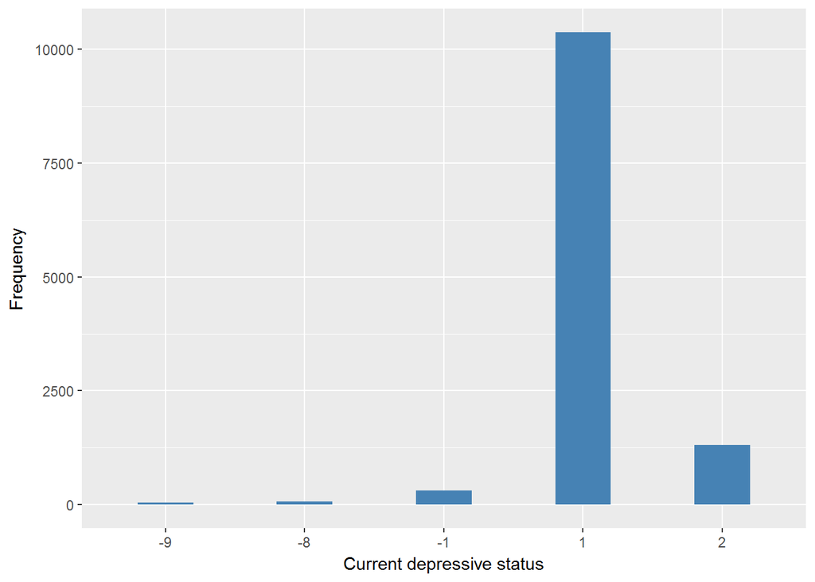

Current depressive status

| Sample size | Missing values |
| --- | --- |
| 12099 | 311 |

Category

|  | -9 | -8 | 1 | 2 |
| --- | --- | --- | --- | --- |
| Frequency | 44.00 | 28.00 | 1595.00 | 10121.00 |
| Percentage | 0.36 | 0.23 | 13.18 | 83.65 |

Type of missing

|  | -17 | -1 | NA |
| --- | --- | --- | --- |
| Frequency | 0 | 311.00 | 0 |
| Percentage | 0 | 2.57 | 0 |

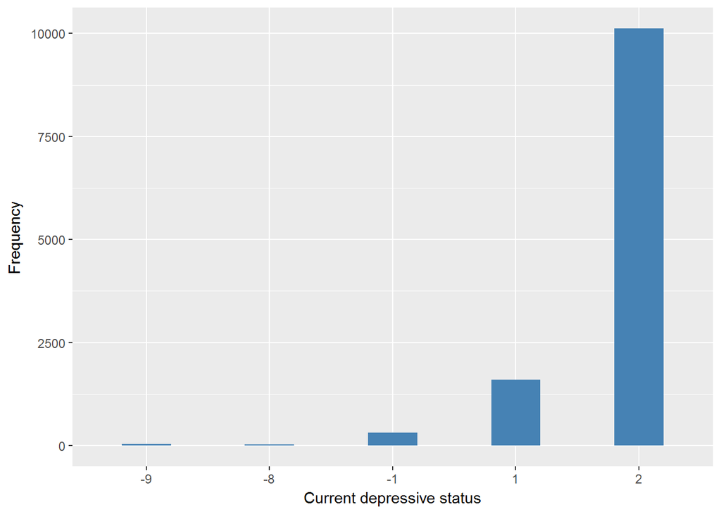

Current depressive status

| Sample size | Missing values |
| --- | --- |
| 12099 | 311 |

Category

|  | -9 | -8 | 1 | 2 |
| --- | --- | --- | --- | --- |
| Frequency | 44.00 | 73.0 | 10534.00 | 1137.0 |
| Percentage | 0.36 | 0.6 | 87.07 | 9.4 |

Type of missing

|  | -17 | -1 | NA |
| --- | --- | --- | --- |
| Frequency | 0 | 311.00 | 0 |
| Percentage | 0 | 2.57 | 0 |

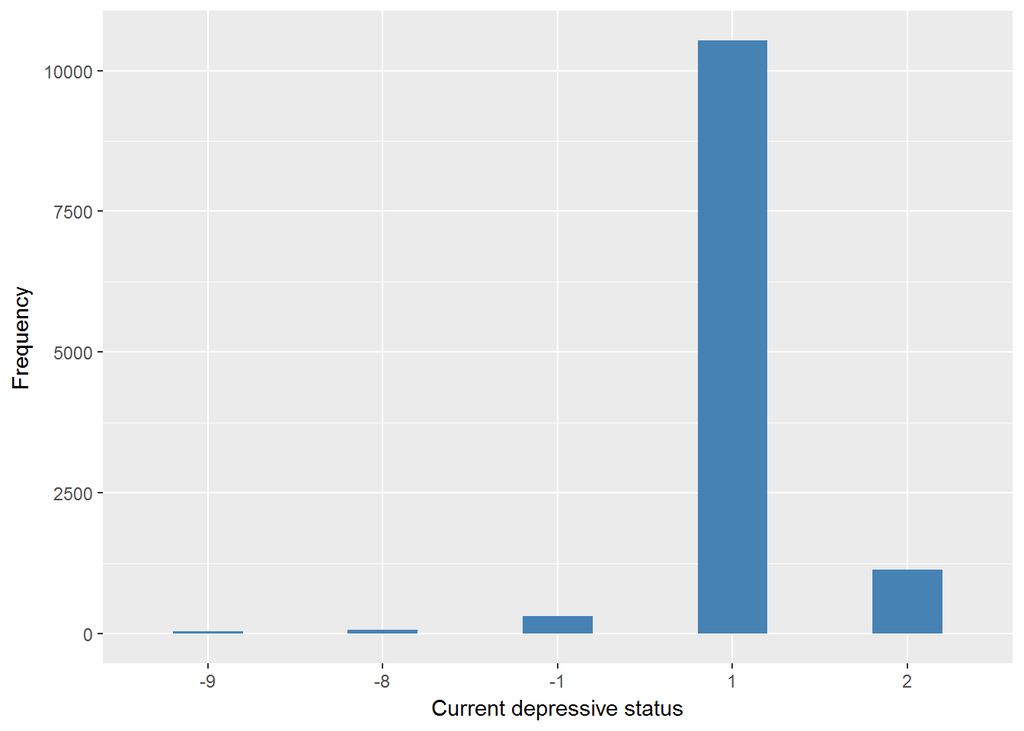

Current depressive status

| Sample size | Missing values |
| --- | --- |
| 12099 | 311 |

Category

|  | -9 | -8 | 1 | 2 |
| --- | --- | --- | --- | --- |
| Frequency | 44.00 | 32.00 | 2436.00 | 9276.00 |
| Percentage | 0.36 | 0.26 | 20.13 | 76.67 |

Type of missing

|  | -17 | -1 | NA |
| --- | --- | --- | --- |
| Frequency | 0 | 311.00 | 0 |
| Percentage | 0 | 2.57 | 0 |

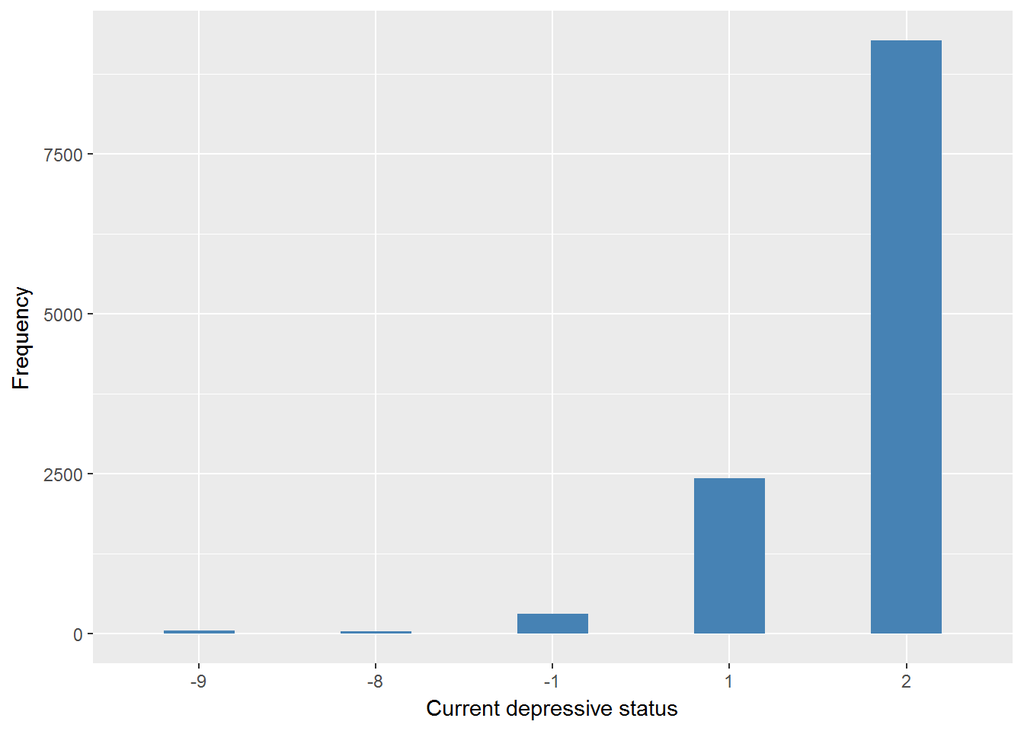

Current depressive status

| Sample size | Missing values |
| --- | --- |
| 12099 | 311 |

Category

|  | -9 | -8 | 1 | 2 |
| --- | --- | --- | --- | --- |
| Frequency | 45.00 | 41.00 | 2547.00 | 9155.00 |
| Percentage | 0.37 | 0.34 | 21.05 | 75.67 |

Type of missing

|  | -17 | -1 | NA |
| --- | --- | --- | --- |
| Frequency | 0 | 311.00 | 0 |
| Percentage | 0 | 2.57 | 0 |

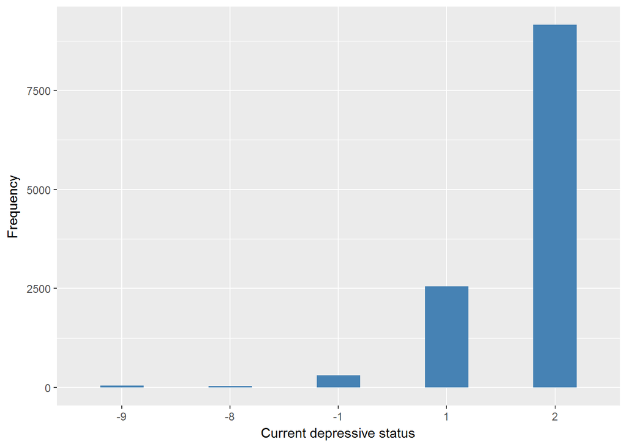

#### 2.1.1.2 Harmonisation algorithm

To compute the harmonized variable from the study-specific variable it has to be recoded as follows:

First of all:

- The reversed items pscedd, pscedf:
  - `recode 1 into 0`
  - `recode 2 into 1`
- The direct items psceda, pscedb, pscedc, pscede, pscedg, pscedh:
  - `keep 1 into 1`
  - `recode 2 into 0`

Secondly in order to get the final score the items have to be summed. If one items is missing, scores on the completed items are summed; the total is divided by the number of items answered and multiplied by 8. If more than 1 items are missing the individual get a missing value in the final score.

After get the final score, it has to be recoded as follows:

- `0-3 into 0`
- `>4 into 1`
- `NA into`
  - `997 if the individual has more items = -9 than -8, -1 and NA`
  - `998 if the individual has more items = -8 than -9, -1 and NA`
  - `996 if the individual has more items = -1 than -9, -8 and NA`
  - `999 if the individual has more items = NA than -8, -9 and -1`

**R script:**

```r
# reversed items
ELSA_dep$pd <- car::recode(ELSA_dep$pscedd, "1=0; 2=1; -8=NA; -9=NA; -1=NA")
ELSA_dep$pf <- car::recode(ELSA_dep$pscedf, "1=0; 2=1; -8=NA; -9=NA; -1=NA")

# direct items
ELSA_dep$pa <- car::recode(ELSA_dep$psceda, "2=0; -8=NA; -9=NA; -1=NA")
ELSA_dep$pb <- car::recode(ELSA_dep$pscedb, "2=0; -8=NA; -9=NA; -1=NA")
ELSA_dep$pc <- car::recode(ELSA_dep$pscedc, "2=0; -8=NA; -9=NA; -1=NA")
ELSA_dep$pe <- car::recode(ELSA_dep$pscede, "2=0; -8=NA; -9=NA; -1=NA")
ELSA_dep$pg <- car::recode(ELSA_dep$pscedg, "2=0; -8=NA; -9=NA; -1=NA")
ELSA_dep$ph <- car::recode(ELSA_dep$pscedh, "2=0; -8=NA; -9=NA; -1=NA")


ELSA_dep$nmiss <- apply(ELSA_dep[, 10:17], MARGIN = 1, FUN = function(x) sum(is.na(x)))


ELSA_dep$final_score <- apply(ELSA_dep[, 10:17], MARGIN = 1, FUN = function(x) sum(x,
    na.rm = TRUE))


ELSA_dep$final_score[which(ELSA_dep$nmiss == 1)] <- (ELSA_dep$final_score[which(ELSA_dep$nmiss ==
    1)]/7) * 8

ELSA_dep$n8 <- apply(ELSA_dep[, 2:9], MARGIN = 1, FUN = function(x) sum(x ==
    (-8), na.rm = TRUE))
ELSA_dep$n9 <- apply(ELSA_dep[, 2:9], MARGIN = 1, FUN = function(x) sum(x ==
    (-9), na.rm = TRUE))
ELSA_dep$n1 <- apply(ELSA_dep[, 2:9], MARGIN = 1, FUN = function(x) sum(x ==
    (-1), na.rm = TRUE))
ELSA_dep$nNA <- apply(ELSA_dep[, 2:9], MARGIN = 1, FUN = function(x) sum(is.na(x)))

ELSA_dep$max_891_NA <- apply(ELSA_dep[, 20:22], MARGIN = 1, FUN = function(x) which.max(x))
ELSA_dep$max_891_NA <- car::recode(ELSA_dep$max_891_NA, "1=998;2=997;3=996;4=999")

ELSA_dep$final_score[which(ELSA_dep$nmiss > 1)] <- ELSA_dep$max_891_NA[which(ELSA_dep$nmiss >
    1)]

ELSA_ds_w1 <- tibble(id = ELSA_dep$id)
ELSA_ds_w1$depression <- car::recode(ELSA_dep$final_score, "0:3.99999999=0; 4:900=1")
ELSA_ds_w1$depression <- labelled(ELSA_ds_w1[[2]], labels = c(`no depression` = 0,
    depression = 1, Missing = 999, `Do not know` = 998, Refuse = 997, `Not applicable` = 996,
    `Does not answer` = 995, `Not attempt not done` = 994, `Disable to measure` = 993,
    Impute = 992, `CAPI interviewer error` = 991))
```

#### 2.1.1.3 Statistical description of the new harmonised variable

Current depressive status

| Sample size | Missing values |
| --- | --- |
| 12099 | 400 |

Category

|  | 0 | 1 |
| --- | --- | --- |
| Frequency | 9776.0 | 1923.00 |
| Percentage | 80.8 | 15.89 |

Type of missing

|  | 991 | 992 | 993 | 994 | 995 | 996 | 997 | 998 | 999 | NA |
| --- | --- | --- | --- | --- | --- | --- | --- | --- | --- | --- |
| Frequency | 0 | 0 | 0 | 0 | 0 | 311.00 | 45.00 | 44.00 | 0 | 0 |
| Percentage | 0 | 0 | 0 | 0 | 0 | 2.57 | 0.37 | 0.36 | 0 | 0 |

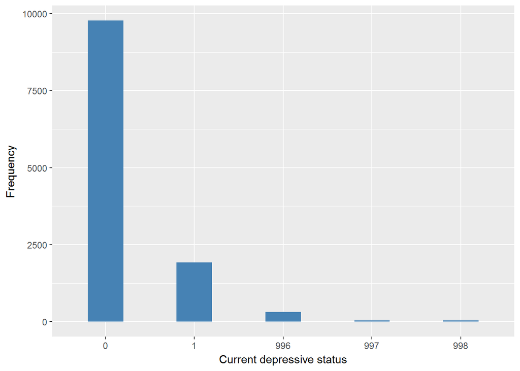

#### 2.1.1.4 Validation

|  | <4->0 | >=4->1 | -1->996 | -9->997 | -8->998 |
| --- | --- | --- | --- | --- | --- |
| BeforeH | 9776 | 1923 | 311 | 45 | 44 |
| AfterH | 9776 | 1923 | 311 | 45 | 44 |

### 2.1.2 Wave 2

#### 2.1.2.1 Study-specific variable description

| **Name** | `PScedA` | `PScedB` | `PScedC` | `PScedD` | `PScedE` | `PScedF` | `PScedG` | `PScedH` |
| --- | --- | --- | --- | --- | --- | --- | --- | --- |
| **Label** | `Whether respondent has felt depressed much of the time during the past week` | `Whether respondent felt everything they did during the past week was an effort` | `Whether respondent felt their sleep was restless during the past week` | `Whether respondent was happy much of the time during the past week` | `Whether respondent felt lonely much of the time during the past week` | `Whether respondent enjoyed life much of the time during the past week` | `Whether respondent felt sad much of the time during the past week` | `Whether respondent could not get going much of the time during the past week` |
| **Table name** | `wave_2_core_data_v4` | `wave_2_core_data_v4` | `wave_2_core_data_v4` | `wave_2_core_data_v4` | `wave_2_core_data_v4` | `wave_2_core_data_v4` | `wave_2_core_data_v4` | `wave_2_core_data_v4` |
| **Categories** | `1 = yes` | `1 = yes` | `1 = yes` | `1 = yes` | `1 = yes` | `1 = yes` | `1 = yes` | `1 = yes` |
|  | `2 = no` | `2 = no` | `2 = no` | `2 = no` | `2 = no` | `2 = no` | `2 = no` | `2 = no` |
| **Missing** | `-9 = Refusal` | `-9 = Refusal` | `-9 = Refusal` | `-9 = Refusal` | `-9 = Refusal` | `-9 = Refusal` | `-9 = Refusal` | `-9 = Refusal` |
|  | `-8 = Don't Know` | `-8 = Don't Know` | `-8 = Don't Know` | `-8 = Don't Know` | `-8 = Don't Know` | `-8 = Don't Know` | `-8 = Don't Know` | `-8 = Don't Know` |
|  | `-1 = Not applicable` | `-1 = Not applicable` | `-1 = Not applicable` | `-1 = Not applicable` | `-1 = Not applicable` | `-1 = Not applicable` | `-1 = Not applicable` | `-1 = Not applicable` |
| **Description** |  |  |  |  |  |  |  |  |

Current depressive status

| Sample size | Missing values |
| --- | --- |
| 9432 | 159 |

Category

|  | -9 | -8 | 1 | 2 |
| --- | --- | --- | --- | --- |
| Frequency | 23.00 | 31.00 | 1515.00 | 7704.00 |
| Percentage | 0.24 | 0.33 | 16.06 | 81.68 |

Type of missing

|  | -17 | -1 | NA |
| --- | --- | --- | --- |
| Frequency | 0 | 159.00 | 0 |
| Percentage | 0 | 1.69 | 0 |

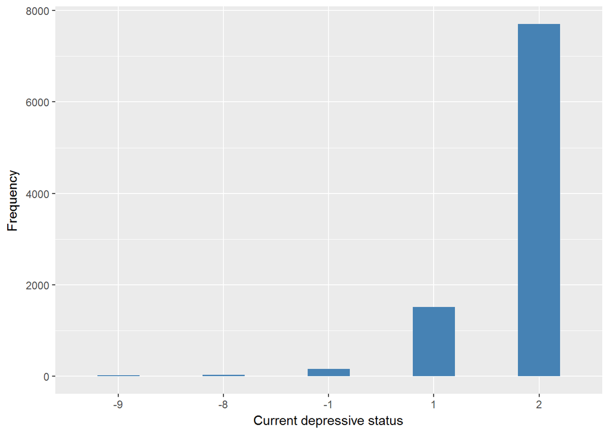

Current depressive status

| Sample size | Missing values |
| --- | --- |
| 9432 | 159 |

Category

|  | -9 | -8 | 1 | 2 |
| --- | --- | --- | --- | --- |
| Frequency | 23.00 | 32.00 | 2066.0 | 7152.00 |
| Percentage | 0.24 | 0.34 | 21.9 | 75.83 |

Type of missing

|  | -17 | -1 | NA |
| --- | --- | --- | --- |
| Frequency | 0 | 159.00 | 0 |
| Percentage | 0 | 1.69 | 0 |

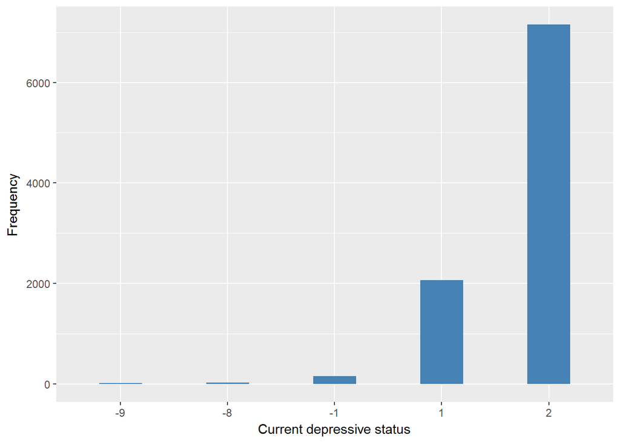

Current depressive status

| Sample size | Missing values |
| --- | --- |
| 9432 | 159 |

Category

|  | -9 | -8 | 1 | 2 |
| --- | --- | --- | --- | --- |
| Frequency | 23.00 | 37.00 | 3885.00 | 5328.00 |
| Percentage | 0.24 | 0.39 | 41.19 | 56.49 |

Type of missing

|  | -17 | -1 | NA |
| --- | --- | --- | --- |
| Frequency | 0 | 159.00 | 0 |
| Percentage | 0 | 1.69 | 0 |

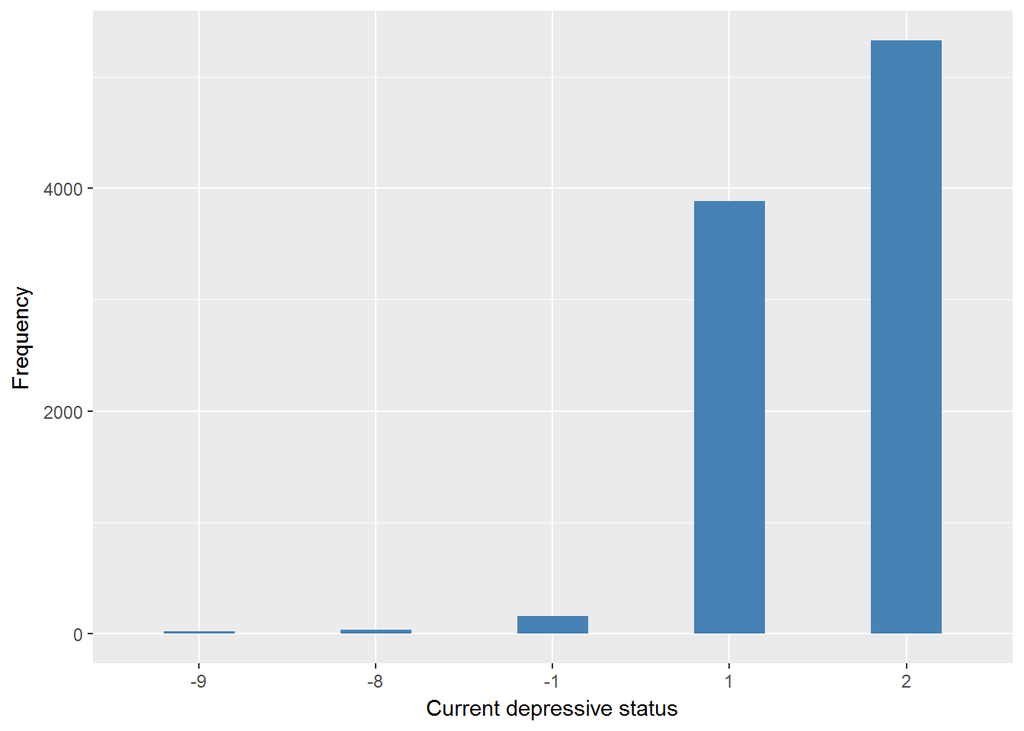

Current depressive status

| Sample size | Missing values |
| --- | --- |
| 9432 | 159 |

Category

|  | -9 | -8 | 1 | 2 |
| --- | --- | --- | --- | --- |
| Frequency | 23.00 | 53.00 | 8223.00 | 974.00 |
| Percentage | 0.24 | 0.56 | 87.18 | 10.33 |

Type of missing

|  | -17 | -1 | NA |
| --- | --- | --- | --- |
| Frequency | 0 | 159.00 | 0 |
| Percentage | 0 | 1.69 | 0 |

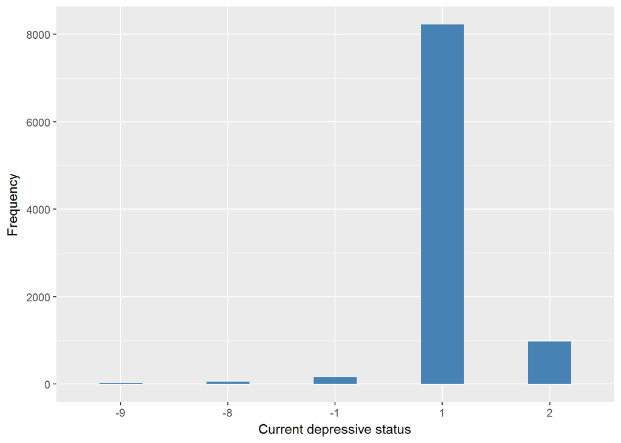

Current depressive status

| Sample size | Missing values |
| --- | --- |
| 9432 | 159 |

Category

|  | -9 | -8 | 1 | 2 |
| --- | --- | --- | --- | --- |
| Frequency | 23.00 | 34.00 | 1275.00 | 7941.00 |
| Percentage | 0.24 | 0.36 | 13.52 | 84.19 |

Type of missing

|  | -17 | -1 | NA |
| --- | --- | --- | --- |
| Frequency | 0 | 159.00 | 0 |
| Percentage | 0 | 1.69 | 0 |

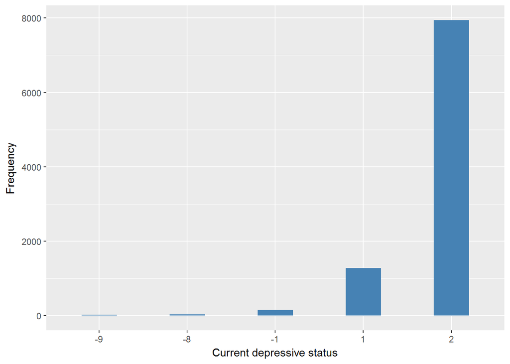

Current depressive status

| Sample size | Missing values |
| --- | --- |
| 9432 | 159 |

Category

|  | -9 | -8 | 1 | 2 |
| --- | --- | --- | --- | --- |
| Frequency | 23.00 | 52.00 | 8291.0 | 907.00 |
| Percentage | 0.24 | 0.55 | 87.9 | 9.62 |

Type of missing

|  | -17 | -1 | NA |
| --- | --- | --- | --- |
| Frequency | 0 | 159.00 | 0 |
| Percentage | 0 | 1.69 | 0 |

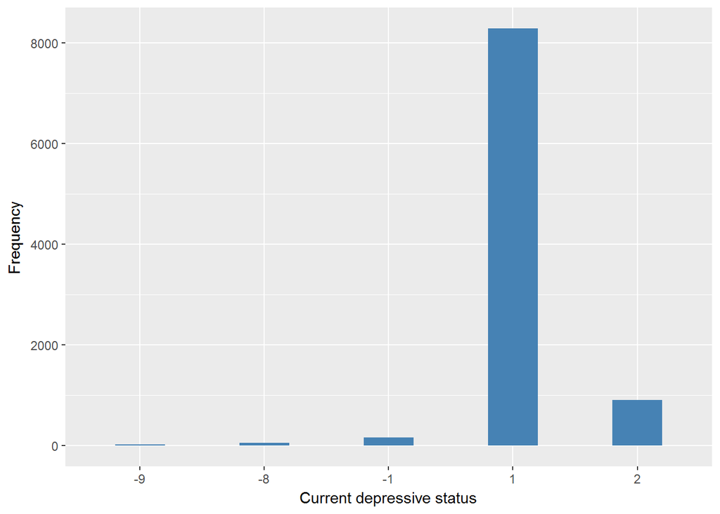

Current depressive status

| Sample size | Missing values |
| --- | --- |
| 9432 | 159 |

Category

|  | -9 | -8 | 1 | 2 |
| --- | --- | --- | --- | --- |
| Frequency | 23.00 | 38.0 | 1961.00 | 7251.00 |
| Percentage | 0.24 | 0.4 | 20.79 | 76.88 |

Type of missing

|  | -17 | -1 | NA |
| --- | --- | --- | --- |
| Frequency | 0 | 159.00 | 0 |
| Percentage | 0 | 1.69 | 0 |

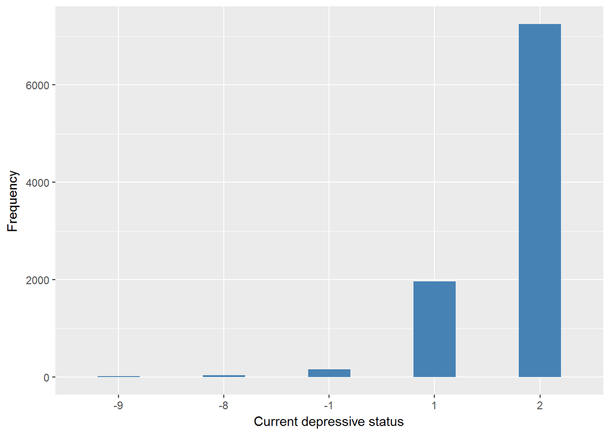

Current depressive status

| Sample size | Missing values |
| --- | --- |
| 9432 | 159 |

Category

|  | -9 | -8 | 1 | 2 |
| --- | --- | --- | --- | --- |
| Frequency | 23.00 | 41.00 | 1940.00 | 7269.00 |
| Percentage | 0.24 | 0.43 | 20.57 | 77.07 |

Type of missing

|  | -17 | -1 | NA |
| --- | --- | --- | --- |
| Frequency | 0 | 159.00 | 0 |
| Percentage | 0 | 1.69 | 0 |

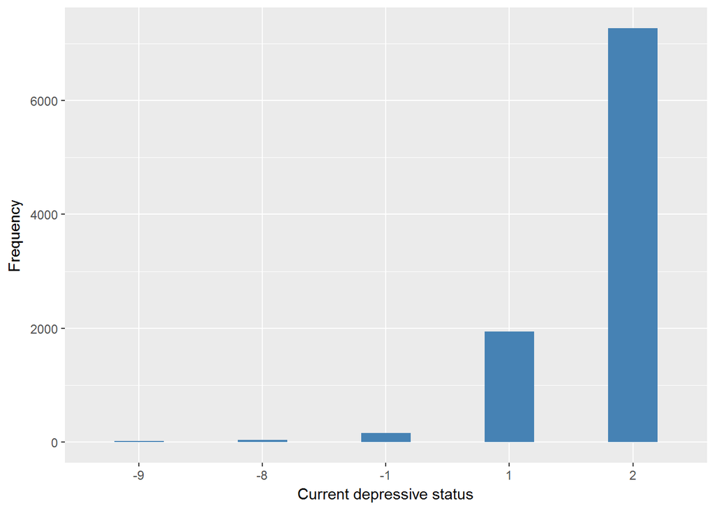

#### 2.1.2.2 Harmonisation algorithm

To compute the harmonized variable from the study-specific variable it has to be recoded as follows:

First of all:

- The reversed items pscedd, pscedf:
  - `recode 1 into 0`
  - `recode 2 into 1`
- The direct items psceda, pscedb, pscedc, pscede, pscedg, pscedh:
  - `keep 1 into 1`
  - `recode 2 into 0`

Secondly in order to get the final score the items have to be summed. If one items is missing, scores on the completed items are summed; the total is divided by the number of items answered and multiplied by 8. If more than 1 items are missing the individual get a missing value in the final score.

After get the final score, it has to be recoded as follows:

- `0-3 into 0`
- `>4 into 1`
- `NA into`
  - `997 if the individual has more items = -9 than -8, -1 and NA`
  - `998 if the individual has more items = -8 than -9, -1 and NA`
  - `996 if the individual has more items = -1 than -9, -8 and NA`
  - `999 if the individual has more items = NA than -8, -9 and -1`

**R script:**

```r
# reversed items
ELSA_dep$pd <- car::recode(ELSA_dep$PScedD, "1=0; 2=1; -8=NA; -9=NA; -1=NA")
ELSA_dep$pf <- car::recode(ELSA_dep$PScedF, "1=0; 2=1; -8=NA; -9=NA; -1=NA")

# direct items
ELSA_dep$pa <- car::recode(ELSA_dep$PScedA, "2=0; -8=NA; -9=NA; -1=NA")
ELSA_dep$pb <- car::recode(ELSA_dep$PScedB, "2=0; -8=NA; -9=NA; -1=NA")
ELSA_dep$pc <- car::recode(ELSA_dep$PScedC, "2=0; -8=NA; -9=NA; -1=NA")
ELSA_dep$pe <- car::recode(ELSA_dep$PScedE, "2=0; -8=NA; -9=NA; -1=NA")
ELSA_dep$pg <- car::recode(ELSA_dep$PScedG, "2=0; -8=NA; -9=NA; -1=NA")
ELSA_dep$ph <- car::recode(ELSA_dep$PScedH, "2=0; -8=NA; -9=NA; -1=NA")


ELSA_dep$nmiss <- apply(ELSA_dep[, 10:17], MARGIN = 1, FUN = function(x) sum(is.na(x)))


ELSA_dep$final_score <- apply(ELSA_dep[, 10:17], MARGIN = 1, FUN = function(x) sum(x,
    na.rm = TRUE))


ELSA_dep$final_score[which(ELSA_dep$nmiss == 1)] <- (ELSA_dep$final_score[which(ELSA_dep$nmiss ==
    1)]/7) * 8

ELSA_dep$n8 <- apply(ELSA_dep[, 2:9], MARGIN = 1, FUN = function(x) sum(x ==
    (-8), na.rm = TRUE))
ELSA_dep$n9 <- apply(ELSA_dep[, 2:9], MARGIN = 1, FUN = function(x) sum(x ==
    (-9), na.rm = TRUE))
ELSA_dep$n1 <- apply(ELSA_dep[, 2:9], MARGIN = 1, FUN = function(x) sum(x ==
    (-1), na.rm = TRUE))
ELSA_dep$nNA <- apply(ELSA_dep[, 2:9], MARGIN = 1, FUN = function(x) sum(is.na(x)))

ELSA_dep$max_891_NA <- apply(ELSA_dep[, 20:22], MARGIN = 1, FUN = function(x) which.max(x))
ELSA_dep$max_891_NA <- car::recode(ELSA_dep$max_891_NA, "1=998;2=997;3=996;4=999")

ELSA_dep$final_score[which(ELSA_dep$nmiss > 1)] <- ELSA_dep$max_891_NA[which(ELSA_dep$nmiss >
    1)]

ELSA_ds_w2 <- tibble(id = ELSA_dep$id)
ELSA_ds_w2$depression <- car::recode(ELSA_dep$final_score, "0:3.99999999=0; 4:900=1")
ELSA_ds_w2$depression <- labelled(ELSA_ds_w2[[2]], labels = c(`no depression` = 0,
    depression = 1, Missing = 999, `Do not know` = 998, Refuse = 997, `Not applicable` = 996,
    `Does not answer` = 995, `Not attempt not done` = 994, `Disable to measure` = 993,
    Impute = 992, `CAPI interviewer error` = 991))
```

#### 2.1.2.3 Statistical description of the new harmonised variable

Current depressive status

| Sample size | Missing values |
| --- | --- |
| 9432 | 217 |

Category

|  | 0 | 1 |
| --- | --- | --- |
| Frequency | 7776.00 | 1439.00 |
| Percentage | 82.44 | 15.26 |

Type of missing

|  | 991 | 992 | 993 | 994 | 995 | 996 | 997 | 998 | 999 | NA |
| --- | --- | --- | --- | --- | --- | --- | --- | --- | --- | --- |
| Frequency | 0 | 0 | 0 | 0 | 0 | 159.00 | 23.00 | 35.00 | 0 | 0 |
| Percentage | 0 | 0 | 0 | 0 | 0 | 1.69 | 0.24 | 0.37 | 0 | 0 |

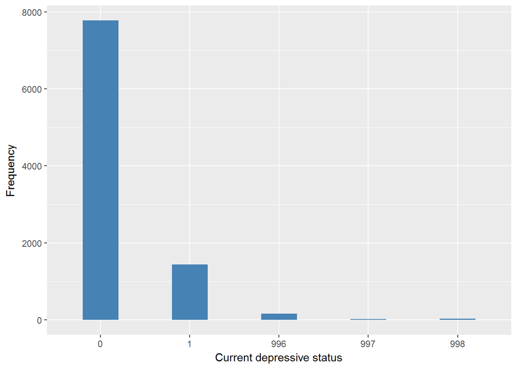

#### 2.1.2.4 Validation

|  | <4->0 | >=4->1 | -1->996 | -9->997 | -8->998 |
| --- | --- | --- | --- | --- | --- |
| BeforeH | 7776 | 1439 | 159 | 23 | 35 |
| AfterH | 7776 | 1439 | 159 | 23 | 35 |

### 2.1.3 Wave 3

#### 2.1.3.1 Study-specific variable description

| **Name** | `psceda` | `pscedb` | `pscedc` | `pscedd` | `pscede` | `pscedf` | `pscedg` | `pscedh` |
| --- | --- | --- | --- | --- | --- | --- | --- | --- |
| **Label** | `Whether respondent has felt depressed much of the time during the past week` | `Whether respondent felt everything they did during the past week was an effort` | `Whether respondent felt their sleep was restless during the past week` | `Whether respondent was happy much of the time during the past week` | `Whether respondent felt lonely much of the time during the past week` | `Whether respondent enjoyed life much of the time during the past week` | `Whether respondent felt sad much of the time during the past week` | `Whether respondent could not get going much of the time during the past week` |
| **Table name** | `wave_3_elsa_data_v4` | `wave_3_elsa_data_v4` | `wave_3_elsa_data_v4` | `wave_3_elsa_data_v4` | `wave_3_elsa_data_v4` | `wave_3_elsa_data_v4` | `wave_3_elsa_data_v4` | `wave_3_elsa_data_v4` |
| **Categories** | `1 = yes` | `1 = yes` | `1 = yes` | `1 = yes` | `1 = yes` | `1 = yes` | `1 = yes` | `1 = yes` |
|  | `2 = no` | `2 = no` | `2 = no` | `2 = no` | `2 = no` | `2 = no` | `2 = no` | `2 = no` |
| **Missing** | `-9 = Refusal` | `-9 = Refusal` | `-9 = Refusal` | `-9 = Refusal` | `-9 = Refusal` | `-9 = Refusal` | `-9 = Refusal` | `-9 = Refusal` |
|  | `-8 = Don't Know` | `-8 = Don't Know` | `-8 = Don't Know` | `-8 = Don't Know` | `-8 = Don't Know` | `-8 = Don't Know` | `-8 = Don't Know` | `-8 = Don't Know` |
|  | `-1 = Not applicable` | `-1 = Not applicable` | `-1 = Not applicable` | `-1 = Not applicable` | `-1 = Not applicable` | `-1 = Not applicable` | `-1 = Not applicable` | `-1 = Not applicable` |
|  | `-2 = Schedule not applicable` | `-2 = Schedule not applicable` | `-2 = Schedule not applicable` | `-2 = Schedule not applicable` | `-2 = Schedule not applicable` | `-2 = Schedule not applicable` | `-2 = Schedule not applicable` | `-2 = Schedule not applicable` |
| **Description** |  |  |  |  |  |  |  |  |

Current depressive status

| Sample size | Missing values |
| --- | --- |
| 9771 | 276 |

Category

|  | -9 | -8 | 1 | 2 |
| --- | --- | --- | --- | --- |
| Frequency | 10.0 | 25.00 | 1453.00 | 8007.00 |
| Percentage | 0.1 | 0.26 | 14.87 | 81.95 |

Type of missing

|  | -17 | -1 | -2 | NA |
| --- | --- | --- | --- | --- |
| Frequency | 0 | 276.00 | 0 | 0 |
| Percentage | 0 | 2.82 | 0 | 0 |

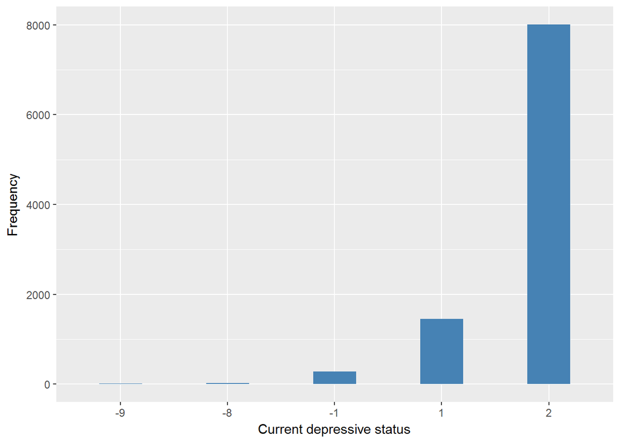

Current depressive status

| Sample size | Missing values |
| --- | --- |
| 9771 | 276 |

Category

|  | -9 | -8 | 1 | 2 |
| --- | --- | --- | --- | --- |
| Frequency | 12.00 | 27.00 | 2003.0 | 7453.00 |
| Percentage | 0.12 | 0.28 | 20.5 | 76.28 |

Type of missing

|  | -17 | -1 | -2 | NA |
| --- | --- | --- | --- | --- |
| Frequency | 0 | 276.00 | 0 | 0 |
| Percentage | 0 | 2.82 | 0 | 0 |

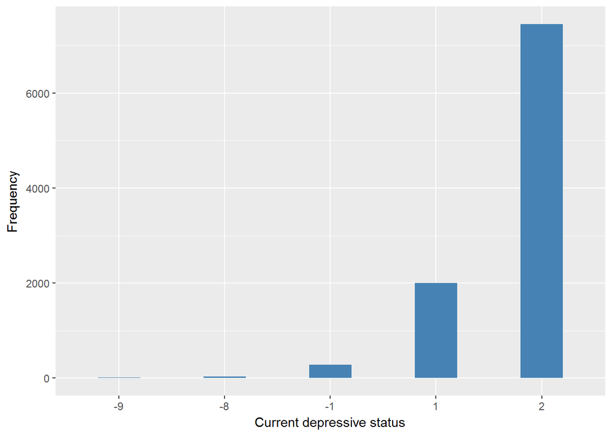

Current depressive status

| Sample size | Missing values |
| --- | --- |
| 9771 | 276 |

Category

|  | -9 | -8 | 1 | 2 |
| --- | --- | --- | --- | --- |
| Frequency | 12.00 | 23.00 | 3891.00 | 5569 |
| Percentage | 0.12 | 0.24 | 39.82 | 57 |

Type of missing

|  | -17 | -1 | -2 | NA |
| --- | --- | --- | --- | --- |
| Frequency | 0 | 276.00 | 0 | 0 |
| Percentage | 0 | 2.82 | 0 | 0 |

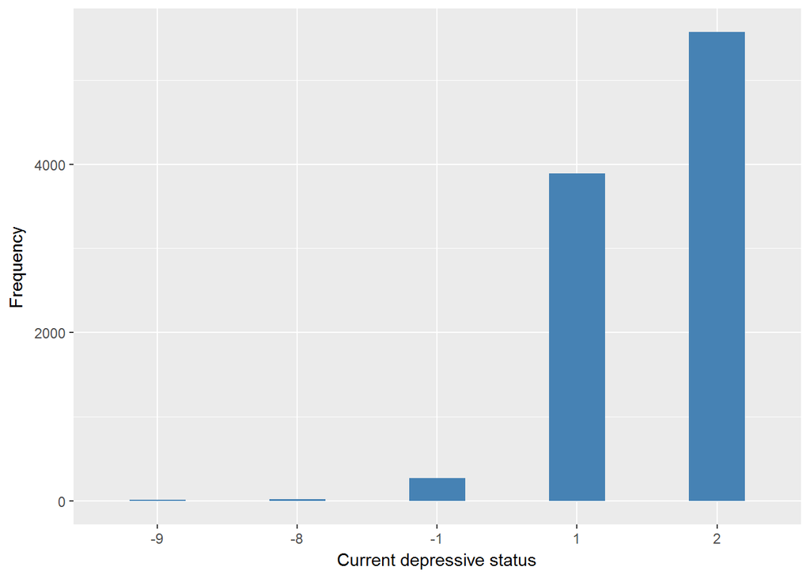

Current depressive status

| Sample size | Missing values |
| --- | --- |
| 9771 | 276 |

Category

|  | -9 | -8 | 1 | 2 |
| --- | --- | --- | --- | --- |
| Frequency | 12.00 | 43.00 | 8404.00 | 1036.0 |
| Percentage | 0.12 | 0.44 | 86.01 | 10.6 |

Type of missing

|  | -17 | -1 | -2 | NA |
| --- | --- | --- | --- | --- |
| Frequency | 0 | 276.00 | 0 | 0 |
| Percentage | 0 | 2.82 | 0 | 0 |

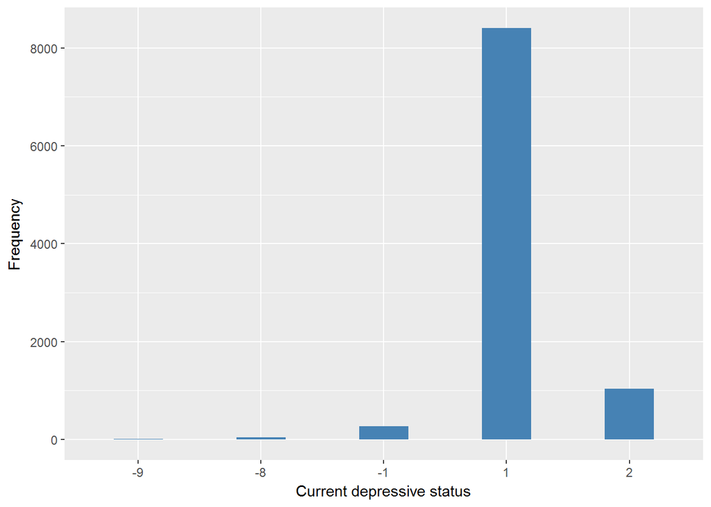

Current depressive status

| Sample size | Missing values |
| --- | --- |
| 9771 | 276 |

Category

|  | -9 | -8 | 1 | 2 |
| --- | --- | --- | --- | --- |
| Frequency | 12.00 | 24.00 | 1252.00 | 8207.00 |
| Percentage | 0.12 | 0.25 | 12.81 | 83.99 |

Type of missing

|  | -17 | -1 | -2 | NA |
| --- | --- | --- | --- | --- |
| Frequency | 0 | 276.00 | 0 | 0 |
| Percentage | 0 | 2.82 | 0 | 0 |

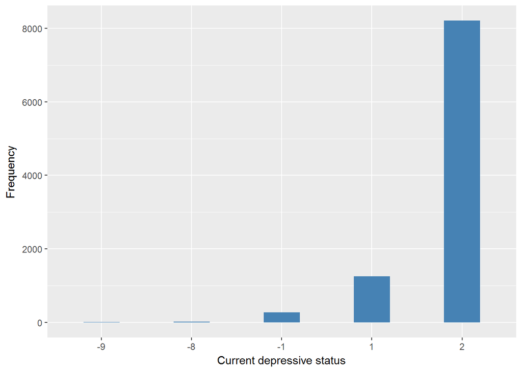

Current depressive status

| Sample size | Missing values |
| --- | --- |
| 9771 | 276 |

Category

|  | -9 | -8 | 1 | 2 |
| --- | --- | --- | --- | --- |
| Frequency | 12.00 | 43.00 | 8505.00 | 935.00 |
| Percentage | 0.12 | 0.44 | 87.04 | 9.57 |

Type of missing

|  | -17 | -1 | -2 | NA |
| --- | --- | --- | --- | --- |
| Frequency | 0 | 276.00 | 0 | 0 |
| Percentage | 0 | 2.82 | 0 | 0 |

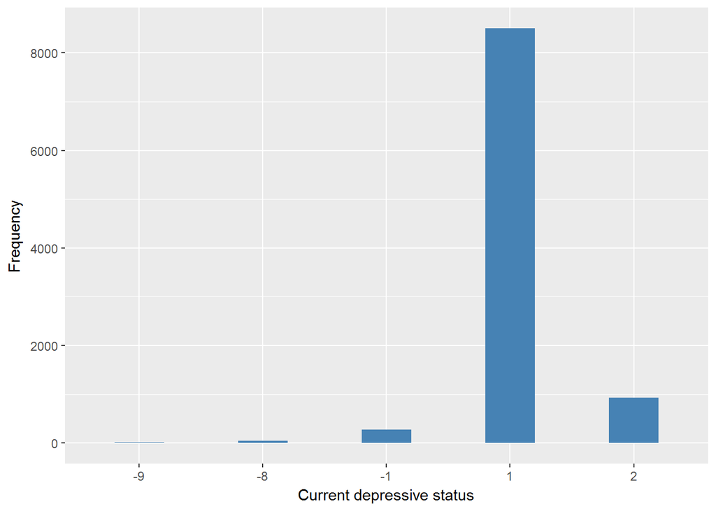

Current depressive status

| Sample size | Missing values |
| --- | --- |
| 9771 | 276 |

Category

|  | -9 | -8 | 1 | 2 |
| --- | --- | --- | --- | --- |
| Frequency | 12.00 | 31.00 | 1853.00 | 7599.00 |
| Percentage | 0.12 | 0.32 | 18.96 | 77.77 |

Type of missing

|  | -17 | -1 | -2 | NA |
| --- | --- | --- | --- | --- |
| Frequency | 0 | 276.00 | 0 | 0 |
| Percentage | 0 | 2.82 | 0 | 0 |

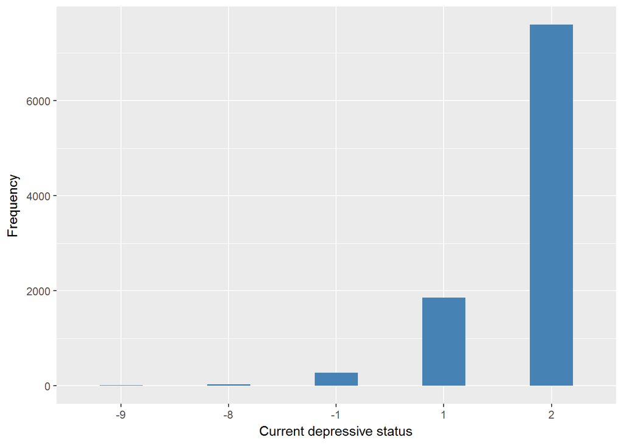

Current depressive status

| Sample size | Missing values |
| --- | --- |
| 9771 | 276 |

Category

|  | -9 | -8 | 1 | 2 |
| --- | --- | --- | --- | --- |
| Frequency | 12.00 | 28.00 | 1984.0 | 7471.00 |
| Percentage | 0.12 | 0.29 | 20.3 | 76.46 |

Type of missing

|  | -17 | -1 | -2 | NA |
| --- | --- | --- | --- | --- |
| Frequency | 0 | 276.00 | 0 | 0 |
| Percentage | 0 | 2.82 | 0 | 0 |

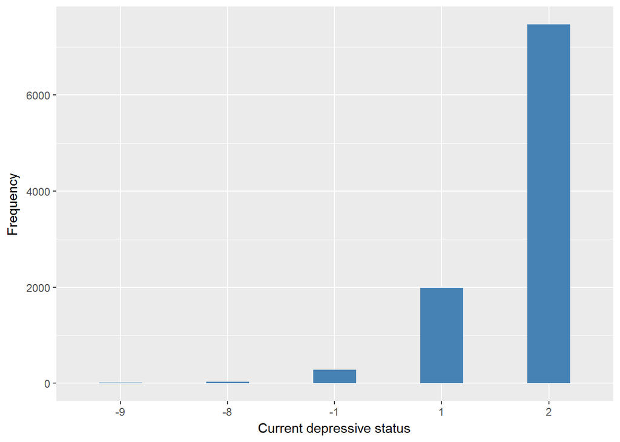

#### 2.1.3.2 Harmonisation algorithm

To compute the harmonized variable from the study-specific variable it has to be recoded as follows:

First of all:

- The reversed items pscedd, pscedf:
  - `recode 1 into 0`
  - `recode 2 into 1`
- The direct items psceda, pscedb, pscedc, pscede, pscedg, pscedh:
  - `keep 1 into 1`
  - `recode 2 into 0`

Secondly in order to get the final score the items have to be summed. If one items is missing, scores on the completed items are summed; the total is divided by the number of items answered and multiplied by 8. If more than 1 items are missing the individual get a missing value in the final score.

**R script:**

```r
# reversed items
ELSA_dep$pd <- car::recode(ELSA_dep$pscedd, "1=0; 2=1; -8=NA; -9=NA; -1=NA; -2=NA")
ELSA_dep$pf <- car::recode(ELSA_dep$pscedf, "1=0; 2=1; -8=NA; -9=NA; -1=NA; -2=NA")

# direct items
ELSA_dep$pa <- car::recode(ELSA_dep$psceda, "2=0; -8=NA; -9=NA; -1=NA; -2=NA")
ELSA_dep$pb <- car::recode(ELSA_dep$pscedb, "2=0; -8=NA; -9=NA; -1=NA; -2=NA")
ELSA_dep$pc <- car::recode(ELSA_dep$pscedc, "2=0; -8=NA; -9=NA; -1=NA; -2=NA")
ELSA_dep$pe <- car::recode(ELSA_dep$pscede, "2=0; -8=NA; -9=NA; -1=NA; -2=NA")
ELSA_dep$pg <- car::recode(ELSA_dep$pscedg, "2=0; -8=NA; -9=NA; -1=NA; -2=NA")
ELSA_dep$ph <- car::recode(ELSA_dep$pscedh, "2=0; -8=NA; -9=NA; -1=NA; -2=NA")


ELSA_dep$nmiss <- apply(ELSA_dep[, 10:17], MARGIN = 1, FUN = function(x) sum(is.na(x)))


ELSA_dep$final_score <- apply(ELSA_dep[, 10:17], MARGIN = 1, FUN = function(x) sum(x,
    na.rm = TRUE))


ELSA_dep$final_score[which(ELSA_dep$nmiss == 1)] <- (ELSA_dep$final_score[which(ELSA_dep$nmiss ==
    1)]/7) * 8

ELSA_dep$n8 <- apply(ELSA_dep[, 2:9], MARGIN = 1, FUN = function(x) sum(x ==
    (-8), na.rm = TRUE))
ELSA_dep$n9 <- apply(ELSA_dep[, 2:9], MARGIN = 1, FUN = function(x) sum(x ==
    (-9), na.rm = TRUE))
ELSA_dep$n12 <- apply(ELSA_dep[, 2:9], MARGIN = 1, FUN = function(x) sum(x %in%
    c(-1, -2), na.rm = TRUE))
ELSA_dep$nNA <- apply(ELSA_dep[, 2:9], MARGIN = 1, FUN = function(x) sum(is.na(x)))

ELSA_dep$max_891_NA <- apply(ELSA_dep[, 20:22], MARGIN = 1, FUN = function(x) which.max(x))
ELSA_dep$max_891_NA <- car::recode(ELSA_dep$max_891_NA, "1=998;2=997;3=996;4=999")

ELSA_dep$final_score[which(ELSA_dep$nmiss > 1)] <- ELSA_dep$max_891_NA[which(ELSA_dep$nmiss >
    1)]

ELSA_ds_w3 <- tibble(id = ELSA_dep$id)
ELSA_ds_w3$depression <- car::recode(ELSA_dep$final_score, "0:3.99999999=0; 4:900=1")
ELSA_ds_w3$depression <- labelled(ELSA_ds_w3[[2]], labels = c(`no depression` = 0,
    depression = 1, Missing = 999, `Do not know` = 998, Refuse = 997, `Not applicable` = 996,
    `Does not answer` = 995, `Not attempt not done` = 994, `Disable to measure` = 993,
    Impute = 992, `CAPI interviewer error` = 991))
```

#### 2.1.3.3 Statistical description of the new harmonised variable

Current depressive status

| Sample size | Missing values |
| --- | --- |
| 9771 | 320 |

Category

|  | 0 | 1 |
| --- | --- | --- |
| Frequency | 8023.00 | 1428.00 |
| Percentage | 82.11 | 14.61 |

Type of missing

|  | 991 | 992 | 993 | 994 | 995 | 996 | 997 | 998 | 999 | NA |
| --- | --- | --- | --- | --- | --- | --- | --- | --- | --- | --- |
| Frequency | 0 | 0 | 0 | 0 | 0 | 276.00 | 12.00 | 32.00 | 0 | 0 |
| Percentage | 0 | 0 | 0 | 0 | 0 | 2.82 | 0.12 | 0.33 | 0 | 0 |

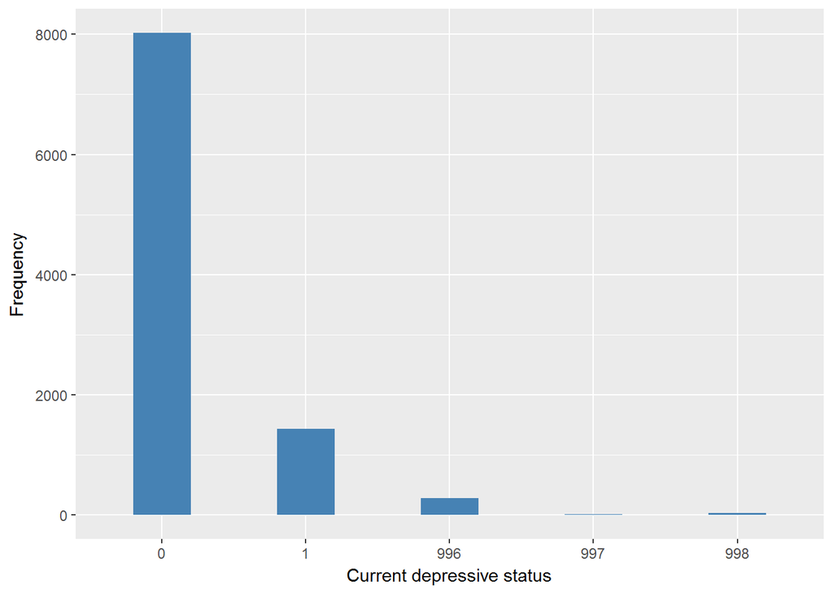

##### 2.1.3.3.1 Validation

|  | <4->0 | >=4->1 | (-1,-2)->996 | -9->997 | -8->998 |
| --- | --- | --- | --- | --- | --- |
| BeforeH | 8023 | 1428 | 276 | 12 | 32 |
| AfterH | 8023 | 1428 | 276 | 12 | 32 |

### 2.1.4 Wave 4

#### 2.1.4.1 Study-specific variable description

| **Name** | `psceda` | `pscedb` | `pscedc` | `pscedd` | `pscede` | `pscedf` | `pscedg` | `pscedh` |
| --- | --- | --- | --- | --- | --- | --- | --- | --- |
| **Label** | `Whether respondent has felt depressed much of the time during the past week` | `Whether respondent felt everything they did during the past week was an effort` | `Whether respondent felt their sleep was restless during the past week` | `Whether respondent was happy much of the time during the past week` | `Whether respondent felt lonely much of the time during the past week` | `Whether respondent enjoyed life much of the time during the past week` | `Whether respondent felt sad much of the time during the past week` | `Whether respondent could not get going much of the time during the past week` |
| **Table name** | `wave_4_elsa_data_v3` | `wave_4_elsa_data_v3` | `wave_4_elsa_data_v3` | `wave_4_elsa_data_v3` | `wave_4_elsa_data_v3` | `wave_4_elsa_data_v3` | `wave_4_elsa_data_v3` | `wave_4_elsa_data_v3` |
| **Categories** | `1 = yes` | `1 = yes` | `1 = yes` | `1 = yes` | `1 = yes` | `1 = yes` | `1 = yes` | `1 = yes` |
|  | `2 = no` | `2 = no` | `2 = no` | `2 = no` | `2 = no` | `2 = no` | `2 = no` | `2 = no` |
| **Missing** | `-9 = Refusal` | `-9 = Refusal` | `-9 = Refusal` | `-9 = Refusal` | `-9 = Refusal` | `-9 = Refusal` | `-9 = Refusal` | `-9 = Refusal` |
|  | `-8 = Don't Know` | `-8 = Don't Know` | `-8 = Don't Know` | `-8 = Don't Know` | `-8 = Don't Know` | `-8 = Don't Know` | `-8 = Don't Know` | `-8 = Don't Know` |
|  | `-1 = Not applicable` | `-1 = Not applicable` | `-1 = Not applicable` | `-1 = Not applicable` | `-1 = Not applicable` | `-1 = Not applicable` | `-1 = Not applicable` | `-1 = Not applicable` |
|  | `-2 = Schedule not applicable` | `-2 = Schedule not applicable` | `-2 = Schedule not applicable` | `-2 = Schedule not applicable` | `-2 = Schedule not applicable` | `-2 = Schedule not applicable` | `-2 = Schedule not applicable` | `-2 = Schedule not applicable` |
| **Description** |  |  |  |  |  |  |  |  |

Current depressive status

| Sample size | Missing values |
| --- | --- |
| 11050 | 446 |

Category

|  | -9 | -8 | 1 | 2 |
| --- | --- | --- | --- | --- |
| Frequency | 63.00 | 16.00 | 1563.00 | 8962.0 |
| Percentage | 0.57 | 0.14 | 14.14 | 81.1 |

Type of missing

|  | -17 | -1 | -2 | NA |
| --- | --- | --- | --- | --- |
| Frequency | 0 | 446.00 | 0 | 0 |
| Percentage | 0 | 4.04 | 0 | 0 |

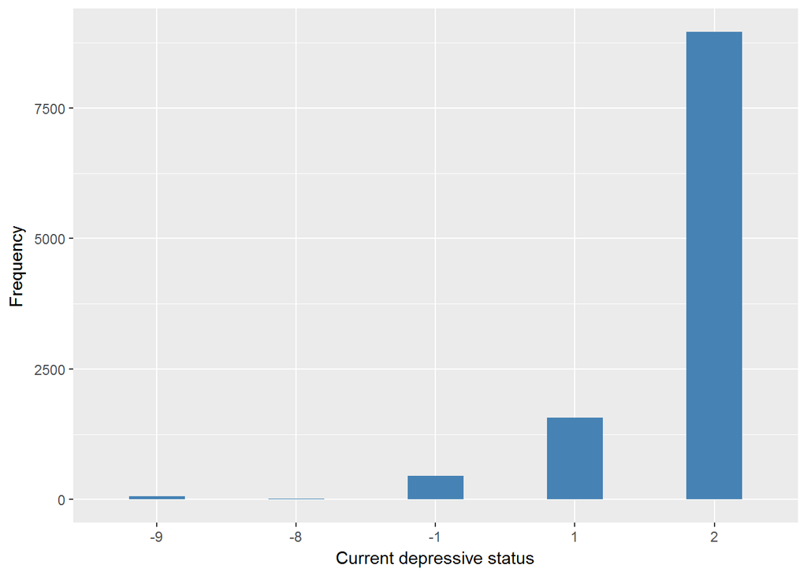

Current depressive status

| Sample size | Missing values |
| --- | --- |
| 11050 | 446 |

Category

|  | -9 | -8 | 1 | 2 |
| --- | --- | --- | --- | --- |
| Frequency | 62.00 | 21.00 | 2081.00 | 8440.00 |
| Percentage | 0.56 | 0.19 | 18.83 | 76.38 |

Type of missing

|  | -17 | -1 | -2 | NA |
| --- | --- | --- | --- | --- |
| Frequency | 0 | 446.00 | 0 | 0 |
| Percentage | 0 | 4.04 | 0 | 0 |

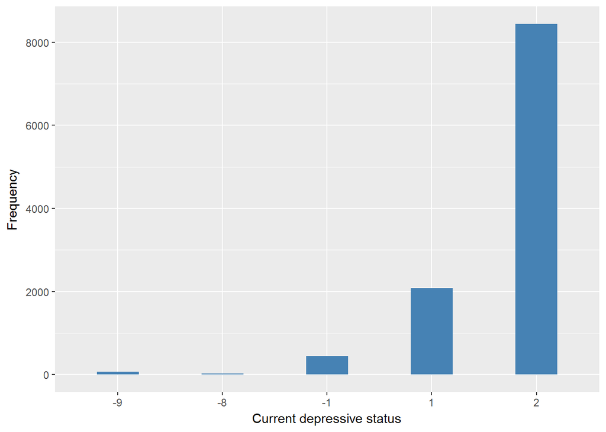

Current depressive status

| Sample size | Missing values |
| --- | --- |
| 11050 | 446 |

Category

|  | -9 | -8 | 1 | 2 |
| --- | --- | --- | --- | --- |
| Frequency | 61.00 | 13.00 | 3697.00 | 6833.00 |
| Percentage | 0.55 | 0.12 | 33.46 | 61.84 |

Type of missing

|  | -17 | -1 | -2 | NA |
| --- | --- | --- | --- | --- |
| Frequency | 0 | 446.00 | 0 | 0 |
| Percentage | 0 | 4.04 | 0 | 0 |

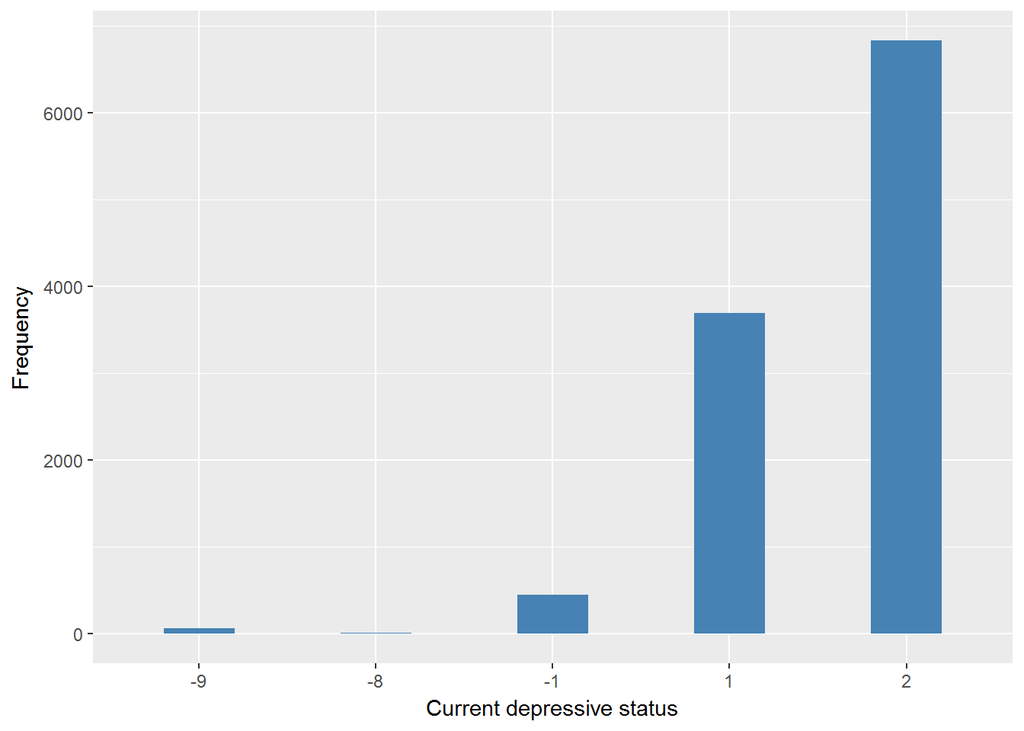

Current depressive status

| Sample size | Missing values |
| --- | --- |
| 11050 | 446 |

Category

|  | -9 | -8 | 1 | 2 |
| --- | --- | --- | --- | --- |
| Frequency | 62.00 | 44.0 | 9390.00 | 1108.00 |
| Percentage | 0.56 | 0.4 | 84.98 | 10.03 |

Type of missing

|  | -17 | -1 | -2 | NA |
| --- | --- | --- | --- | --- |
| Frequency | 0 | 446.00 | 0 | 0 |
| Percentage | 0 | 4.04 | 0 | 0 |